# US Census People Analytics Case Study

*Library imports for Data Analysis and Manipulation*

```python
import pandas as pd
import numpy as np
import matplotlib.pyplot as plt
import seaborn as sns
import missingno
sns.set_style('whitegrid')

import warnings
warnings.filterwarnings('ignore')
```

*Reading the salary data and checking first 3 rows of dataset*

```python
census_data=pd.read_csv('data.csv')
census_data.head(3)
```

|  | Unnamed: 0 | Age | WorkClass | fnlwgt | Education | EducationNum | MaritalStatus | Occupation | Relationship | Gender | CapitalGain | CapitalLoss | HoursPerWeek | NativeCountry | Income |
| --- | --- | --- | --- | --- | --- | --- | --- | --- | --- | --- | --- | --- | --- | --- | --- |
| 0 | 0 | 39.0 | State-gov | 77516.0 | Bachelors | 13.0 | Never-married | Adm-clerical | Not-in-family | Male | 2174.0 | 0.0 | 40.0 | United-States | <=50K |
| 1 | 1 | 50.0 | Self-emp-not-inc | 83311.0 | Bachelors | 13.0 | Married-civ-spouse | NaN | Husband | Male | 0.0 | 0.0 | 13.0 | United-States | <=50K |
| 2 | 2 | 38.0 | Private | 215646.0 | HS-grad | 9.0 | Divorced | Handlers-cleaners | Not-in-family | Male | 0.0 | 0.0 | 40.0 | United-States | <=50K |

## Exploratory Data Analysis

*Checking the column types and total number of records for each variables against the number of records for our dependent or response variable*

```python
census_data.info()
```

```
<class 'pandas.core.frame.DataFrame'>
RangeIndex: 40935 entries, 0 to 40934
Data columns (total 15 columns):
Unnamed: 0       40935 non-null int64
Age              38194 non-null float64
WorkClass        38146 non-null object
fnlwgt           38149 non-null float64
Education        38192 non-null object
EducationNum     38132 non-null float64
MaritalStatus    38011 non-null object
Occupation       38176 non-null object
Relationship     38120 non-null object
Gender           38208 non-null object
CapitalGain      38129 non-null float64
CapitalLoss      38217 non-null float64
HoursPerWeek     38255 non-null float64
NativeCountry    38206 non-null object
Income           40935 non-null object
dtypes: float64(6), int64(1), object(8)
memory usage: 4.7+ MB
```

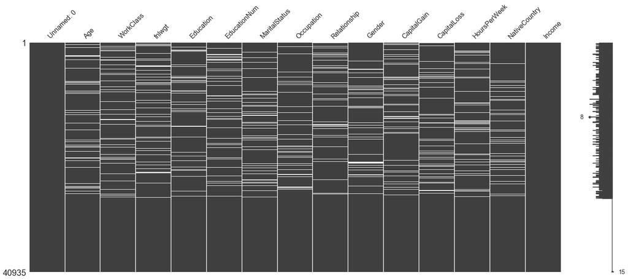

```python
missingno.matrix(census_data)
```

```python
census_data.isnull().sum()
```

```
Unnamed: 0          0
Age              2741
WorkClass        2789
fnlwgt           2786
Education        2743
EducationNum     2803
MaritalStatus    2924
Occupation       2759
Relationship     2815
Gender           2727
CapitalGain      2806
CapitalLoss      2718
HoursPerWeek     2680
NativeCountry    2729
Income              0
dtype: int64
```

*We have almost 2800 records that are missing for each of our independent variable or feature variables*

**Continuous Variable distribution**

```python
census_data.describe()
```

|  | Unnamed: 0 | Age | fnlwgt | EducationNum | CapitalGain | CapitalLoss | HoursPerWeek |
| --- | --- | --- | --- | --- | --- | --- | --- |
| count | 40935.000000 | 38194.000000 | 3.814900e+04 | 38132.000000 | 38129.000000 | 38217.000000 | 38255.000000 |
| mean | 14002.280518 | 38.591585 | 1.898043e+05 | 10.080169 | 1076.079467 | 88.536934 | 40.407136 |
| std | 9133.039458 | 13.682749 | 1.059296e+05 | 2.570247 | 7440.867512 | 406.104097 | 12.432823 |
| min | 0.000000 | 17.000000 | 1.228500e+04 | 1.000000 | 0.000000 | 0.000000 | 1.000000 |
| 25% | 6352.500000 | 28.000000 | 1.174440e+05 | 9.000000 | 0.000000 | 0.000000 | 40.000000 |
| 50% | 12711.000000 | 37.000000 | 1.782510e+05 | 10.000000 | 0.000000 | 0.000000 | 40.000000 |
| 75% | 21277.500000 | 48.000000 | 2.378680e+05 | 12.000000 | 0.000000 | 0.000000 | 45.000000 |
| max | 32560.000000 | 90.000000 | 1.490400e+06 | 16.000000 | 99999.000000 | 4356.000000 | 99.000000 |

*Even the 75th percentile has zeroes for CapitalGain & CapitalLoss, I am considering dropping these variables from the model*

**Categorical variable distribution**

```python
census_data.describe(include=['object'])
```

|  | WorkClass | Education | MaritalStatus | Occupation | Relationship | Gender | NativeCountry | Income |
| --- | --- | --- | --- | --- | --- | --- | --- | --- |
| count | 38146 | 38192 | 38011 | 38176 | 38120 | 38208 | 38206 | 40935 |
| unique | 9 | 16 | 7 | 15 | 6 | 2 | 42 | 4 |
| top | Private | HS-grad | Married-civ-spouse | Prof-specialty | Husband | Male | United-States | <=50K |
| freq | 26529 | 12356 | 17342 | 4836 | 15336 | 25506 | 34265 | 21121 |

**Variable: Income**

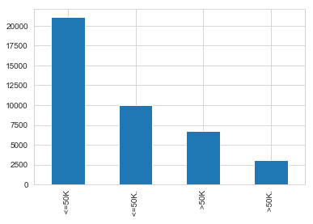

```python
census_data['Income'].value_counts().plot(kind='bar')
```

*Here we have mislabelling or typo where it adds a (.) to our labels. Encoding them to 0 for (<50K & <50K.) and 1 for (>50K & >50K.) - Handled in the data cleaning/wrangling section*

**Variable: Age**

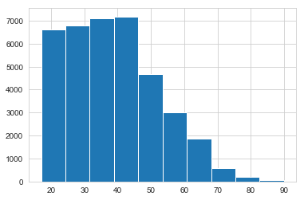

```python
census_data['Age'].hist()
```

*Majority of ages are between 25 and 50 years*

**Variable: Education & EducationNum**

*The two columns 'Education' and 'EducationNum'seem to have a mapping for some kind*

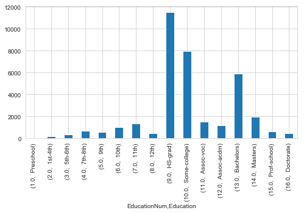

```python
plt.figure(figsize=(8,4))
census_data.groupby(['EducationNum','Education'])['Income'].count().plot('bar')
```

*They are directly correlated, We have a direct mapping for Education, we won't have to encode them, I will perform the mapping since when one is available the other maybe not available, that way we are increasing information gain*

**Variable: WorkClass**

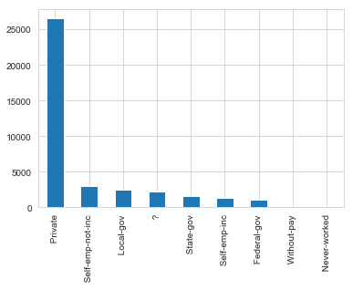

```python
census_data['WorkClass'].value_counts().plot(kind='bar')
```

*Work Class is heavily skewed with 'Private' and it makes sense too, We also have a special character (?) in WorkClass Variable, I am assuming that this is a null placeholder hence I will encode it to null in the Data Cleansing/Wrangling Section for better representation of data*

**Variable: fnlwgt**

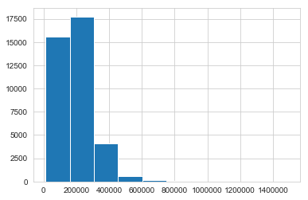

```python
census_data['fnlwgt'].hist()
```

*fnlwgt has really not much info to gather, so I will be dropping it from the model*

**Variable: CapitalGain**

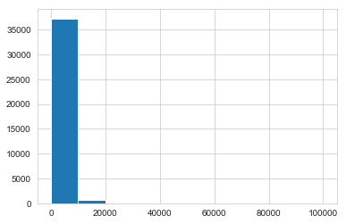

```python
census_data['CapitalGain'].hist()
```

*Most of the records have 0 capital gain, again not much information for the model*

**Variable: CapitalLoss**

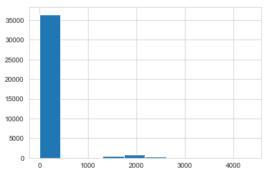

```python
census_data['CapitalLoss'].hist()
```

*Most of the records have 0 capital loss, again not much information for the model*

**Variable: Gender**

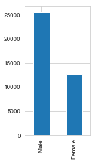

```python
plt.figure(figsize=(2,4))
census_data['Gender'].value_counts().plot(kind='bar')
```

*Almost double the sample size of males compared to females*

**Variable: Occupation**

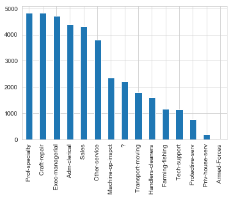

```python
census_data['Occupation'].value_counts().plot(kind='bar')
```

*There's good distribution of occupation, but here also we have a special character (?) in Occupation Variable, I am assuming that this is a null placeholder hence I will encode it to null in the Data Cleansing/Wrangling Section for better representation of data*

**Variable: Relationship**

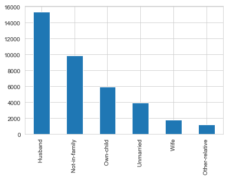

```python
census_data['Relationship'].value_counts().plot(kind='bar')
```

**Variable: MaritalStatus**

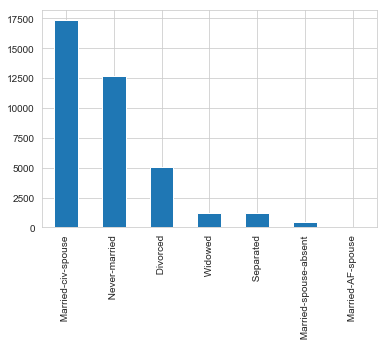

```python
census_data['MaritalStatus'].value_counts().plot(kind='bar')
```

**Variable: Hours/Week**

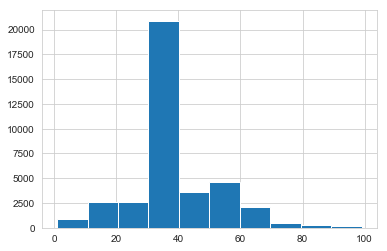

```python
census_data['HoursPerWeek'].hist()
```

*Most individual fall into 30-40 hrs/week bracket, which is representative of real world situation*

**Variable: NativeCountry**

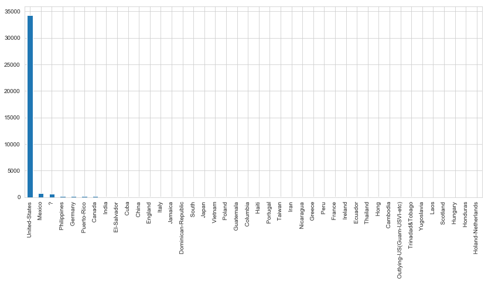

```python
plt.figure(figsize=(14,6))
census_data['NativeCountry'].value_counts().plot(kind='bar')
```

*United States is the native country for over 75% of records, this can heavily bias the data, but country is an important detail to be considered*

*Here also we have a special character (?), I am assuming that this is a null placeholder hence I will encode it to null in the Data Cleansing/Wrangling Section for better representation of data*

## Data Cleansing/Wrangling on the original dataset

First running on the original dataset, Later on I would also need to run it on the final('test') dataset

**Identified anomalies**

1. Column: Unnamed: 0
2. Special Character: ?
3. White Spaces
4. Manipulating Education/EducationNum

**FUNCTION: strip_space**

```python
def strip_space(d):
    '''Strips white spaces from the dataframe columns of type Object'''
    df_obj = d.select_dtypes(['object'])
    #Selecting the Object type variables because numeric variables doesnt have white spaces
    d[df_obj.columns] = df_obj.apply(lambda x: x.str.strip())
    return d
```

**FUNCTION: replace_unknowns**

```python
def replace_unknowns(d):
    '''Replaces ? with nulls'''
    d=strip_space(d)
    #Run strip_space first before
    d.replace('?',np.NaN,inplace=True)
    return d
```

**FUNCTION: mapp_education**

```python
def mapp_education(d):
    '''Mapping Education to EducationNum based on a dictionary derived from grouping Education and EducationNum fields'''
    presence=d['EducationNum'].isna()
    for index in d.index:
        if presence[index]:
            key = d.loc[index, 'Education']
            d.loc[index, 'EducationNum'] = Education_dictionary[key]
    d['EducationNum'].replace(0,np.NaN,inplace=True)
    #Education field not needed we will use EducationNum field instead
    d.drop(['Education'],axis=1,inplace=True)
    return d
```

### Dirty Area for Data Cleansing and Manipulation

```python
census_data.rename(columns={'Unnamed: 0':'File_Index'},inplace=True)
data=census_data.drop(['File_Index'],axis=1)
```

*The dataset was supposed to have two classes, but here I can see that it has 4. Need further analysis on that*

```python
data['Income'].value_counts()
```

```
 <=50K     21121
 <=50K.    10002
 >50K       6719
 >50K.      3093
Name: Income, dtype: int64
```

*Encoding 0 for (<50K & <50K.) and 1 for (>50K & >50K.)*

```python
data['Income'].apply(lambda x: 1 if x =='>50K' or x=='>50K.' else 0).value_counts()
```

```
0    40935
Name: Income, dtype: int64
```

*Mapping didn't work as intended, I found out that it was because of white spaces in the value, hence using the strip_space function*

```python
data = strip_space(data)
```

*Remapping the target variables to 0 for (<50K & <50K.) and 1 for (>50K & >50K.)*

```python
data['Income']=data['Income'].apply(lambda x: 1 if x =='>50K' or x=='>50K.' else 0)
```

```
0    0.760303
1    0.239697
Name: Income, dtype: float64
```

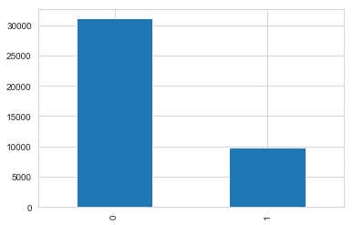

```python
print(data['Income'].value_counts(normalize=True))
data['Income'].value_counts().plot(kind='bar')
```

*The target variable is imbalanced with apprrox 76% class labels for <50K Income level and 24% for >50K Income level*

*Handling '?' using replace_unknowns function, assuming that they are null values I am replacing them with NaN's*

```python
data = replace_unknowns(data)
```

```python
data.groupby(['EducationNum','Education'])['Income'].count()
```

```
EducationNum  Education
1.0           Preschool          61
2.0           1st-4th           186
3.0           5th-6th           359
4.0           7th-8th           687
5.0           9th               566
6.0           10th             1007
7.0           11th             1348
8.0           12th              467
9.0           HS-grad         11502
10.0          Some-college     7949
11.0          Assoc-voc        1502
12.0          Assoc-acdm       1169
13.0          Bachelors        5870
14.0          Masters          1958
15.0          Prof-school       599
16.0          Doctorate         436
Name: Income, dtype: int64
```

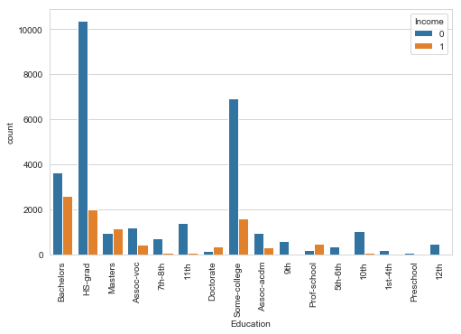

```python
plt.figure(figsize=(8,5))
sns.countplot(x='Education',data=data,hue='Income')
plt.xticks(rotation=90)
```

*Individuals with Higher level of education have greater chances of earning >50k*

```python
data[(data['Education'].notnull()) & (data['EducationNum'].isnull())]['Education'].count()
```

```
2526
```

*Filling Education Num based on Education field, since there were 2526 EducationNum records that were blank where Education was present*

*Taking a few records for validating if our mapping works correctly*

```python
data.iloc[[15,18,43,48,52],:]
```

|  | Age | WorkClass | fnlwgt | Education | EducationNum | MaritalStatus | Occupation | Relationship | Gender | CapitalGain | CapitalLoss | HoursPerWeek | NativeCountry | Income |
| --- | --- | --- | --- | --- | --- | --- | --- | --- | --- | --- | --- | --- | --- | --- |
| 15 | 25.0 | Self-emp-not-inc | 176756.0 | HS-grad | NaN | NaN | Farming-fishing | NaN | Male | NaN | 0.0 | 35.0 | United-States | 0 |
| 18 | 40.0 | Private | 193524.0 | Doctorate | NaN | Married-civ-spouse | NaN | Husband | Male | 0.0 | NaN | 60.0 | United-States | 1 |
| 43 | NaN | Private | 32275.0 | Some-college | NaN | Married-civ-spouse | Exec-managerial | Wife | Female | 0.0 | 0.0 | 40.0 | United-States | 0 |
| 48 | NaN | Private | 216666.0 | 5th-6th | NaN | Married-civ-spouse | Machine-op-inspct | Husband | Male | 0.0 | 0.0 | 40.0 | NaN | 0 |
| 52 | 32.0 | NaN | 293936.0 | 7th-8th | NaN | Married-spouse-absent | NaN | Not-in-family | Male | 0.0 | 0.0 | 40.0 | NaN | 0 |

```python
Education_dictionary = {edu: edu_num for edu, edu_num in zip(data['Education'], data['EducationNum']) if edu != 0}
#Handling for records where both are null
Education_dictionary[np.NaN]=0
data=mapp_education(data)
```

*We dont need the Education field anymore since we already have EducationNum field, hence dropped it in the function itself*

```python
data.iloc[[15,18,43,48,52],:]
```

|  | Age | WorkClass | fnlwgt | EducationNum | MaritalStatus | Occupation | Relationship | Gender | CapitalGain | CapitalLoss | HoursPerWeek | NativeCountry | Income |
| --- | --- | --- | --- | --- | --- | --- | --- | --- | --- | --- | --- | --- | --- |
| 15 | 25.0 | Self-emp-not-inc | 176756.0 | 9.0 | NaN | Farming-fishing | NaN | Male | NaN | 0.0 | 35.0 | United-States | 0 |
| 18 | 40.0 | Private | 193524.0 | 16.0 | Married-civ-spouse | NaN | Husband | Male | 0.0 | NaN | 60.0 | United-States | 1 |
| 43 | NaN | Private | 32275.0 | 10.0 | Married-civ-spouse | Exec-managerial | Wife | Female | 0.0 | 0.0 | 40.0 | United-States | 0 |
| 48 | NaN | Private | 216666.0 | 3.0 | Married-civ-spouse | Machine-op-inspct | Husband | Male | 0.0 | 0.0 | 40.0 | NaN | 0 |
| 52 | 32.0 | NaN | 293936.0 | 4.0 | Married-spouse-absent | NaN | Not-in-family | Male | 0.0 | 0.0 | 40.0 | NaN | 0 |

## Data Exploration on relatively clean data with target Variable

**Variable: Age**

*Creating age range to see how it affects the income levels*

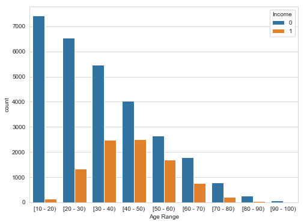

```python
age_ranges = ["[{0} - {1})".format(age, age + 10) for age in range(10, 100, 10)]
data['Age Range'] = pd.cut(x=data['Age'], bins=len(age_ranges), labels=age_ranges)

plt.figure(figsize=(8,6))
sns.countplot(x='Age Range',hue='Income',data=data)
```

*As the age increases, the gap in earning >50K decreases*

*Creating Hours/week range to see how it affects the income levels*

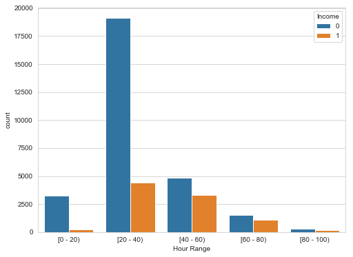

```python
hour_ranges = ["[{0} - {1})".format(hr, hr + 20) for hr in range(0, 100, 20)]
data['Hour Range'] = pd.cut(x=data['HoursPerWeek'], bins=len(hour_ranges), labels=hour_ranges)

plt.figure(figsize=(8,6))
sns.countplot(x='Hour Range',hue='Income',data=data)
```

```
Value Distribution for column: WorkClass
```

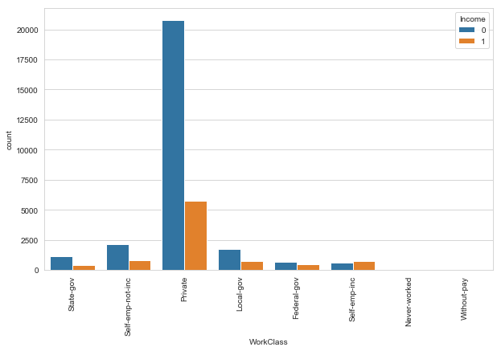

```
Value Distribution for column: MaritalStatus
```

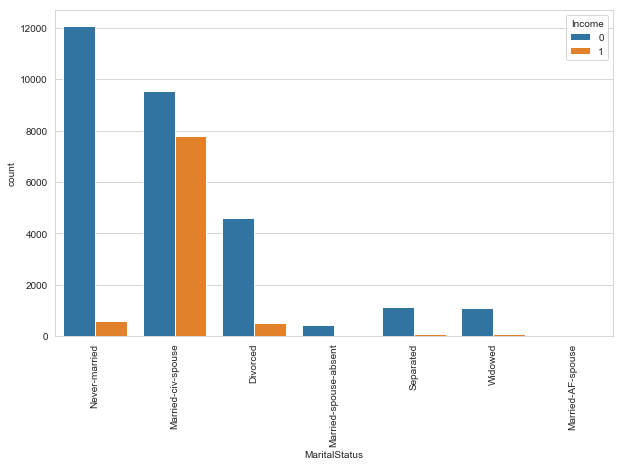

```
Value Distribution for column: Occupation
```

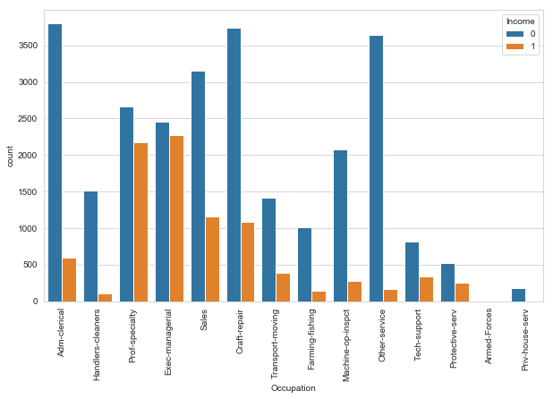

```
Value Distribution for column: Relationship
```

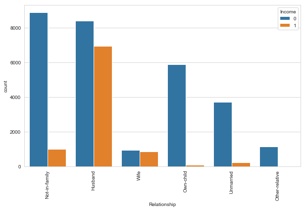

```
Value Distribution for column: Gender
```

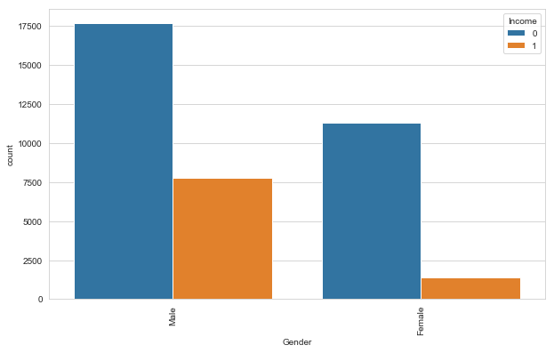

```
Value Distribution for column: NativeCountry
```

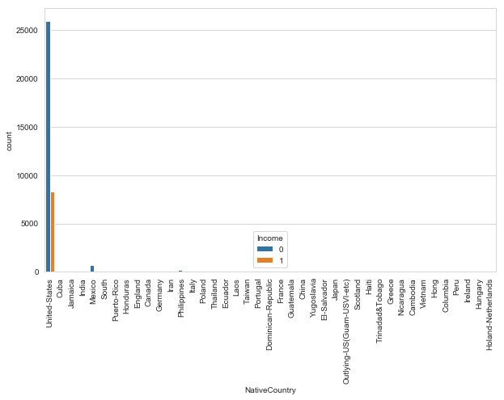

```python
sns.set_style('whitegrid')
df_obj = data.select_dtypes(['object'])
def value_distribution(data):
    for columns in df_obj.columns:
        print('Value Distribution for column:',columns)
        plt.figure(figsize=(10,6))
        sns.countplot(x=columns,data=data,hue='Income')
        plt.xticks(rotation=90)
        plt.show()
        print('\n')

value_distribution(data)
```

*From the above plots we can genralize that Male's have a higher chance of earning >50K than female's, If an individual is in a professional speciality or at a managerial level they tend to earn >50k, If an individual is working >40hours their chance of earning >50K increases*

## Data Cleansing on the test/final dataset

```python
final_data=pd.read_csv('final.csv')
final_data.head(3)
```

|  | Unnamed: 0 | Age | WorkClass | fnlwgt | Education | EducationNum | MaritalStatus | Occupation | Relationship | Gender | CapitalGain | CapitalLoss | HoursPerWeek | NativeCountry |
| --- | --- | --- | --- | --- | --- | --- | --- | --- | --- | --- | --- | --- | --- | --- |
| 0 | 391 | 27.0 | Private | 301302.0 | Bachelors | 13.0 | Never-married | Craft-repair | Not-in-family | Male | 0.0 | 0.0 | 50.0 | United-States |
| 1 | 1899 | 23.0 | Private | 119838.0 | Bachelors | 13.0 | Never-married | Prof-specialty | NaN | Male | 0.0 | 0.0 | NaN | United-States |
| 2 | 24506 | 21.0 | Private | 113106.0 | Some-college | 10.0 | Never-married | NaN | Own-child | Female | NaN | 0.0 | 30.0 | United-States |

```python
final_data.rename(columns={'Unnamed: 0':'File_Index'},inplace=True)
final=final_data.drop(['File_Index'],axis=1)
```

```python
final = strip_space(final)
```

*Handling '?' using replace_unknowns function, assuming that they are null values I am replacing them with NaN's*

```python
final = replace_unknowns(final)
```

```python
final[(final['Education'].notnull()) & (final['EducationNum'].isnull())]['Education'].count()
```

```
297
```

*Filling Education Num based on Education field, since there were 297 EducationNum records that were blank where Education was present*

*Taking a few records for validating if our mapping works correctly*

```python
final.iloc[[13,29,41,47],:]
```

|  | Age | WorkClass | fnlwgt | Education | EducationNum | MaritalStatus | Occupation | Relationship | Gender | CapitalGain | CapitalLoss | HoursPerWeek | NativeCountry |
| --- | --- | --- | --- | --- | --- | --- | --- | --- | --- | --- | --- | --- | --- |
| 13 | 27.0 | Private | 36851.0 | Assoc-voc | NaN | Married-civ-spouse | Sales | Husband | Male | 0.0 | 0.0 | 35.0 | United-States |
| 29 | 28.0 | Private | 129460.0 | 10th | NaN | Widowed | Adm-clerical | Unmarried | Female | 0.0 | 2238.0 | NaN | United-States |
| 41 | 25.0 | Private | NaN | HS-grad | NaN | Never-married | Adm-clerical | Unmarried | Female | 0.0 | 0.0 | 46.0 | NaN |
| 47 | 35.0 | Private | 111128.0 | 10th | NaN | Never-married | NaN | Own-child | Male | 0.0 | 0.0 | 40.0 | United-States |

```python
final=mapp_education(final)
```

*We dont need the Education field anymore since we already have EducationNum field, hence dropped it in the function itself*

```python
final.iloc[[13,29,41,47],:]
```

|  | Age | WorkClass | fnlwgt | EducationNum | MaritalStatus | Occupation | Relationship | Gender | CapitalGain | CapitalLoss | HoursPerWeek | NativeCountry |
| --- | --- | --- | --- | --- | --- | --- | --- | --- | --- | --- | --- | --- |
| 13 | 27.0 | Private | 36851.0 | 11.0 | Married-civ-spouse | Sales | Husband | Male | 0.0 | 0.0 | 35.0 | United-States |
| 29 | 28.0 | Private | 129460.0 | 6.0 | Widowed | Adm-clerical | Unmarried | Female | 0.0 | 2238.0 | NaN | United-States |
| 41 | 25.0 | Private | NaN | 9.0 | Never-married | Adm-clerical | Unmarried | Female | 0.0 | 0.0 | 46.0 | NaN |
| 47 | 35.0 | Private | 111128.0 | 6.0 | Never-married | NaN | Own-child | Male | 0.0 | 0.0 | 40.0 | United-States |

## Feature Engineering - Label Encoding

*Since we have Categorical variables I want them to be encoded for building the model*

```python
from sklearn import preprocessing
from sklearn.experimental import enable_iterative_imputer
from sklearn.impute import IterativeImputer
```

**Merging for Label Encoder**

```python
data_for_encoding=data.drop(['Income','Age Range','Hour Range'],axis=1)
data_for_encoding.head(1)
```

|  | Age | WorkClass | fnlwgt | EducationNum | MaritalStatus | Occupation | Relationship | Gender | CapitalGain | CapitalLoss | HoursPerWeek | NativeCountry |
| --- | --- | --- | --- | --- | --- | --- | --- | --- | --- | --- | --- | --- |
| 0 | 39.0 | State-gov | 77516.0 | 13.0 | Never-married | Adm-clerical | Not-in-family | Male | 2174.0 | 0.0 | 40.0 | United-States |

```python
final.head(1)
```

[output not shown]

```python
#Adding dummy variable to keep track of orignal and test dataset
final['Train']=0
data_for_encoding['Train']=1
```

```python
combined_data=pd.concat([data_for_encoding,final])
```

*Dropping least significant variables*

```python
combined_data.drop(['CapitalGain','CapitalLoss','fnlwgt'],axis=1,inplace=True)
```

*Replacing NaN in categorical Variables with NONE for label encoding*

```python
columns=combined_data.select_dtypes('object').columns
for col in columns:
    combined_data[col].fillna('None',inplace=True)
```

```python
combined_data.iloc[[1,5,10,9,13,15],:]
```

|  | Age | WorkClass | EducationNum | MaritalStatus | Occupation | Relationship | Gender | HoursPerWeek | NativeCountry | Train |
| --- | --- | --- | --- | --- | --- | --- | --- | --- | --- | --- |
| 1 | 50.0 | Self-emp-not-inc | 13.0 | Married-civ-spouse | None | Husband | Male | 13.0 | United-States | 1 |
| 5 | 37.0 | Private | 14.0 | Married-civ-spouse | Exec-managerial | Wife | Female | 40.0 | None | 1 |
| 10 | NaN | None | 13.0 | Married-civ-spouse | Prof-specialty | None | Male | 40.0 | India | 1 |
| 9 | 42.0 | Private | 13.0 | Married-civ-spouse | Exec-managerial | None | Male | 40.0 | None | 1 |
| 13 | 40.0 | Private | 11.0 | Married-civ-spouse | Craft-repair | Husband | None | 40.0 | None | 1 |
| 15 | 25.0 | Self-emp-not-inc | 9.0 | None | Farming-fishing | None | Male | 35.0 | United-States | 1 |

*Label Encoding Now*

```python
le = preprocessing.LabelEncoder()
def label_encode(d):
    for column_name in d.columns:
        if d[column_name].dtype == object:
            d[column_name] = le.fit_transform(d[column_name])
        else:
            pass
    return d
```

```python
combined_data=label_encode(combined_data)
```

```python
combined_data.iloc[[1,5,10,9,13,15],:]
```

|  | Age | WorkClass | EducationNum | MaritalStatus | Occupation | Relationship | Gender | HoursPerWeek | NativeCountry | Train |
| --- | --- | --- | --- | --- | --- | --- | --- | --- | --- | --- |
| 1 | 50.0 | 6 | 13.0 | 2 | 7 | 0 | 1 | 13.0 | 39 | 1 |
| 5 | 37.0 | 4 | 14.0 | 2 | 3 | 6 | 0 | 40.0 | 27 | 1 |
| 10 | NaN | 3 | 13.0 | 2 | 10 | 1 | 1 | 40.0 | 18 | 1 |
| 9 | 42.0 | 4 | 13.0 | 2 | 3 | 1 | 1 | 40.0 | 27 | 1 |
| 13 | 40.0 | 4 | 11.0 | 2 | 2 | 0 | 2 | 40.0 | 27 | 1 |
| 15 | 25.0 | 6 | 9.0 | 5 | 4 | 1 | 1 | 35.0 | 39 | 1 |

*Eyeballing None's Numerical replacement*

Occupation : None - 7

WorkClass : None - 3

NativeCountry : None - 27

MartialStatus : None - 5

Gender : None - 2

Relationship : None - 1

*Replace None's Numerical counterpart to null for Imputation through IterativeImputer*

```python
combined_data['WorkClass'].replace(3,np.NaN,inplace=True)
combined_data['MaritalStatus'].replace(5,np.NaN,inplace=True)
combined_data['Occupation'].replace(7,np.NaN,inplace=True)
combined_data['Relationship'].replace(1,np.NaN,inplace=True)
combined_data['Gender'].replace(2,np.NaN,inplace=True)
combined_data['NativeCountry'].replace(27,np.NaN,inplace=True)
```

## Data Prep for Modelling

*Saving Multiple copies of Cleansed data*

```python
safe_copy=combined_data.copy()
safe_copy1=combined_data.copy()
```

```python
safe_copy_imputer=combined_data.copy()
```

```python
safe_copy_imputer.drop('Train',axis=1,inplace=True)
```

```python
imp = IterativeImputer(add_indicator=False, estimator=None,
                 imputation_order='ascending', initial_strategy='constant',
                 max_iter=10, max_value=None, min_value=None,
                 missing_values=np.NaN,
                 random_state=0, sample_posterior=False, tol=0.001,
                 verbose=0)

imp.fit(safe_copy_imputer)
df_imputed=pd.DataFrame(np.round(imp.transform(safe_copy_imputer)))
df_imputed.columns=safe_copy_imputer.columns
df_imputed.index=safe_copy_imputer.index
```

```python
model_data_encoded_imputed=pd.concat([df_imputed,safe_copy['Train']],axis=1)
```

```python
model_train_data=model_data_encoded_imputed[model_data_encoded_imputed['Train']==1]
final_test_data=model_data_encoded_imputed[model_data_encoded_imputed['Train']==0]
```

*Since we have already split the data, I am gonna drop the dummy Variable Train*

```python
model_train_data.drop('Train',axis=1,inplace=True)
final_test_data.drop('Train',axis=1,inplace=True)
```

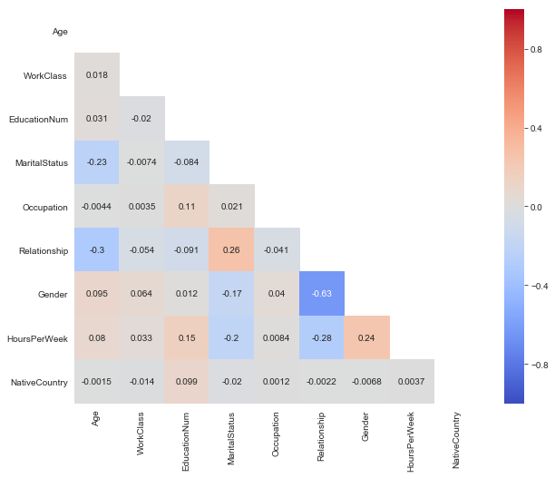

```python
#Plotting Correlation plot
plt.figure(figsize=(10,8))
corrmat = model_train_data.corr()
mask = np.zeros_like(corrmat, dtype=np.bool)
mask[np.triu_indices_from(mask)] = True
sns.heatmap(corrmat,
            vmin=-1,
            cmap='coolwarm',
            annot=True,
            mask = mask);
```

*Gender and Relationship have a high -ve multicolinearity, We should drop relationship variable from the model*

```python
model_train_data=pd.concat([model_train_data,data['Income']],axis=1)
```

```python
y=model_train_data['Income']
X=model_train_data.drop('Income',axis=1)
```

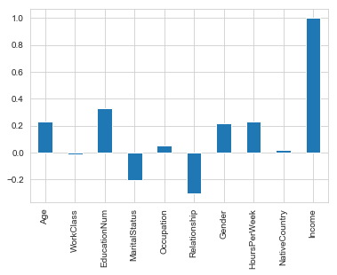

```python
cor_with_income=model_train_data.corrwith(model_train_data['Income'])
cor_with_income.plot(kind='bar')
```

## Feature Selection

```python
import scipy.stats as stats
from scipy.stats import chi2_contingency
```

*The Null hypothesis is that there is NO association between both variables. The Alternate hypothesis says there is evidence to suggest there is an association between the two variables.*

```python
df=model_train_data.copy()
```

```python
df['Check_if_chisquare_works'] = np.random.choice([0, 1], size=(len(df),), p=[0.5, 0.5])
```

```python
def _print_chisquare_result(col, alpha):
    result = ""
    if p<alpha:
        result="{0} is important feature for Prediction".format(col)
    else:
        result="{0} is not an important feature for prediction".format(col)
    print(result)
```

```python
dfObserved=None
alpha=0.05
for col in df.drop('Income',axis=1).columns:
    X_ = df[col].astype(str)
    Y_ = df['Income'].astype(str)
    dfObserved = pd.crosstab(Y_,X_)
    chi2, p, dof, expected = stats.chi2_contingency(dfObserved.values)
    dfExpected = pd.DataFrame(expected, columns=dfObserved.columns, index = dfObserved.index)
    _print_chisquare_result(col,alpha)
```

```
Age is important feature for Prediction
WorkClass is important feature for Prediction
EducationNum is important feature for Prediction
MaritalStatus is important feature for Prediction
Occupation is important feature for Prediction
Relationship is important feature for Prediction
Gender is important feature for Prediction
HoursPerWeek is important feature for Prediction
NativeCountry is important feature for Prediction
Check_if_chisquare_works is not an important feature for prediction
```

## Modelling

```python
from sklearn.metrics import classification_report,confusion_matrix,accuracy_score
from sklearn.model_selection import train_test_split,KFold, GridSearchCV,cross_val_score
#model imports
from sklearn import svm,tree
from sklearn.ensemble import RandomForestClassifier
import xgboost
from imblearn.ensemble import BalancedRandomForestClassifier
from sklearn.linear_model import RidgeClassifierCV,LogisticRegression
```

```python
def plot_confusion_matrix(cm):
    '''A function to show labeled confusion matrix'''
    plt.figure(figsize=(5,4))
    ax= plt.subplot()
    sns.heatmap(cm,fmt='g', annot=True, ax = ax,cmap=plt.cm.Blues);
    # labels, title and ticks
    ax.set_xlabel('Predicted labels');ax.set_ylabel('True labels');
    ax.set_title('Confusion Matrix');
    ax.xaxis.set_ticklabels(['<=50K','>50K']); ax.yaxis.set_ticklabels(['<=50K','>50K']);
```

### Forest model with all the variables

```python
X_train,X_test,y_train,y_test=train_test_split(X,y,test_size=0.33,shuffle=True,stratify=y,random_state=0)
```

```
Training Score:  0.9614599285349669
Testing Score:  0.8141239173884077


Classification Report:
               precision    recall  f1-score   support

           0       0.86      0.91      0.88     10271
           1       0.64      0.53      0.58      3238

    accuracy                           0.81     13509
   macro avg       0.75      0.72      0.73     13509
weighted avg       0.80      0.81      0.81     13509
```

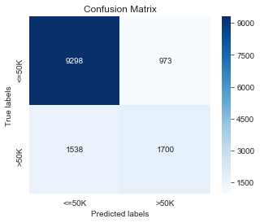

```python
forest_classifier = RandomForestClassifier(random_state = 1, criterion = 'gini')
forest_classifier.fit(X_train,y_train)
print('Training Score: ',forest_classifier.score(X_train,y_train))
print('Testing Score: ',forest_classifier.score(X_test,y_test))
print('\n')
y_pred=forest_classifier.predict(X_test)
print('Classification Report: \n',classification_report(y_test,y_pred))
plot_confusion_matrix(confusion_matrix(y_test,y_pred))
```

*Clearly the model is overfitting*

### Forest Classifier with some features removed

```python
X_train.drop(['Relationship','MaritalStatus','NativeCountry','WorkClass'],axis=1,inplace=True)
X_test.drop(['Relationship','MaritalStatus','NativeCountry','WorkClass'],axis=1,inplace=True)
```

```
Training Score:  0.9106687085247576
Testing Score:  0.7861425716189208


Classification Report:
               precision    recall  f1-score   support

           0       0.84      0.89      0.86     10271
           1       0.57      0.45      0.50      3238

    accuracy                           0.79     13509
   macro avg       0.70      0.67      0.68     13509
weighted avg       0.77      0.79      0.78     13509
```

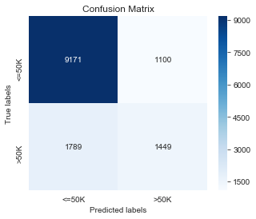

```python
forest_classifier_dropped_features = RandomForestClassifier(random_state = 1, criterion = 'gini')
forest_classifier_dropped_features.fit(X_train,y_train)
print('Training Score: ',forest_classifier_dropped_features.score(X_train,y_train))
print('Testing Score: ',forest_classifier_dropped_features.score(X_test,y_test))
print('\n')
y_pred=forest_classifier_dropped_features.predict(X_test)
print('Classification Report: \n',classification_report(y_test,y_pred))
plot_confusion_matrix(confusion_matrix(y_test,y_pred))
```

### Logistic Regression

```
Training Score:  0.7307664260191059
Testing Score:  0.7320304981863942


Classification Report:
               precision    recall  f1-score   support

           0       0.90      0.73      0.81     10271
           1       0.46      0.74      0.57      3238

    accuracy                           0.73     13509
   macro avg       0.68      0.73      0.69     13509
weighted avg       0.79      0.73      0.75     13509
```

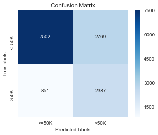

```python
logistic_regression=LogisticRegression(class_weight='balanced')
logistic_regression.fit(X_train,y_train)
print('Training Score: ',logistic_regression.score(X_train,y_train))
print('Testing Score: ',logistic_regression.score(X_test,y_test))
print('\n')
y_pred=logistic_regression.predict(X_test)
print('Classification Report: \n',classification_report(y_test,y_pred))
plot_confusion_matrix(confusion_matrix(y_test,y_pred))
```

### XGB Classifier

```
Training Score:  0.8086851892364909
Testing Score:  0.813087571248797


Classification Report:
               precision    recall  f1-score   support

           0       0.87      0.89      0.88     10271
           1       0.62      0.58      0.60      3238

    accuracy                           0.81     13509
   macro avg       0.74      0.73      0.74     13509
weighted avg       0.81      0.81      0.81     13509
```

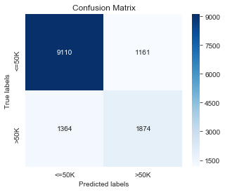

```python
xgb = xgboost.XGBClassifier(scale_pos_weight=1.5)
xgb.fit(X_train,y_train)
print('Training Score: ',xgb.score(X_train,y_train))
print('Testing Score: ',xgb.score(X_test,y_test))
print('\n')
y_pred=xgb.predict(X_test)
print('Classification Report: \n',classification_report(y_test,y_pred))
plot_confusion_matrix(confusion_matrix(y_test,y_pred))
```

### Ridge Classifier

```
Training Score:  0.7288704149347335
Testing Score:  0.7295136575616256


Classification Report:
               precision    recall  f1-score   support

           0       0.90      0.73      0.80     10271
           1       0.46      0.74      0.57      3238

    accuracy                           0.73     13509
   macro avg       0.68      0.73      0.69     13509
weighted avg       0.79      0.73      0.75     13509
```

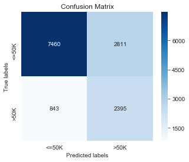

```python
ridge_classifier=RidgeClassifierCV(class_weight='balanced')
ridge_classifier.fit(X_train,y_train)
print('Training Score: ',ridge_classifier.score(X_train,y_train))
print('Testing Score: ',ridge_classifier.score(X_test,y_test))
print('\n')
y_pred=ridge_classifier.predict(X_test)
print('Classification Report: \n',classification_report(y_test,y_pred))
plot_confusion_matrix(confusion_matrix(y_test,y_pred))
```

### Balanced Random Forest Classifier

```
0.7946838766134325
0.7400251684062477
              precision    recall  f1-score   support

           0       0.91      0.73      0.81     10271
           1       0.47      0.77      0.59      3238

    accuracy                           0.74     13509
   macro avg       0.69      0.75      0.70     13509
weighted avg       0.81      0.74      0.76     13509
```

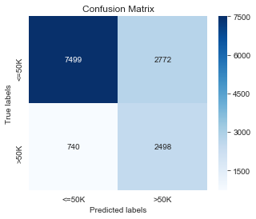

```python
balancedforest=BalancedRandomForestClassifier()
balancedforest.fit(X_train,y_train)
print(balancedforest.score(X_train,y_train))
print(balancedforest.score(X_test,y_test))
y_pred=balancedforest.predict(X_test)
print(classification_report(y_test,y_pred))
plot_confusion_matrix(confusion_matrix(y_test,y_pred))
```

## Output and Conclusion

[figure not shown]

```python
plot_confusion_matrix(confusion_matrix(y_test,y_pred))
```

```python
#Predicting the outputs and saving it to csv file
X_final_test=final_test_data.drop(['Relationship','MaritalStatus','NativeCountry','WorkClass'],axis=1)
Y_final_test=pd.DataFrame()
Y_final_test['Income']=xgb.predict(X_final_test)
Y_final_test['Income']=Y_final_test['Income'].map({0:'<=50K',1:'>50K'})
```

```python
Y_final_test.to_csv('predicted_labels.csv')
predicted_labels_with_records=pd.concat([final_data,Y_final_test['Income']],axis=1)
predicted_labels_with_records.to_csv('predicted_labels_with_records.csv')
```